# Homework 9

## Problem 1

### 1.1

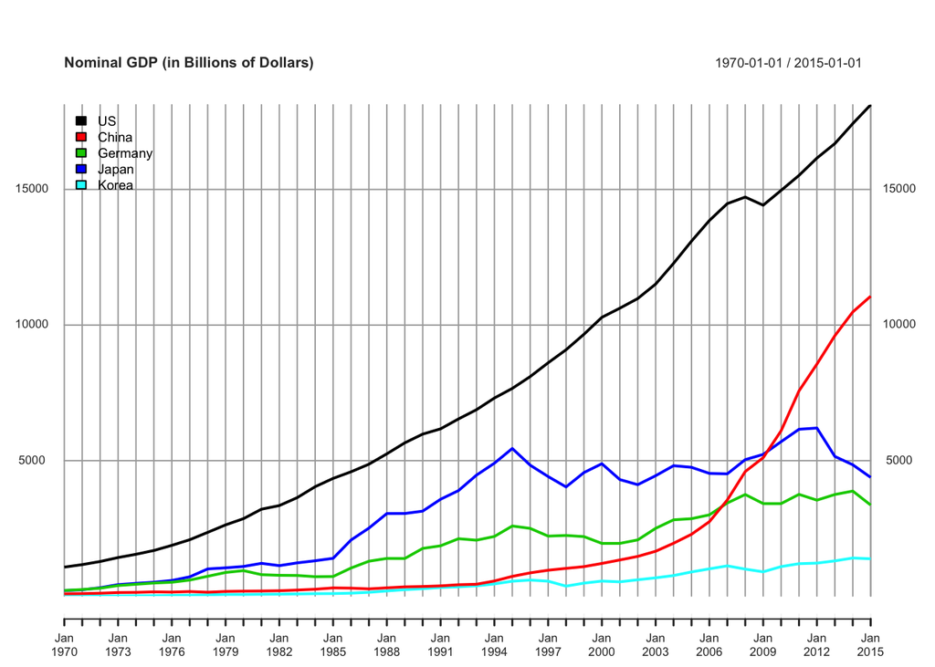

```r
library(quantmod)
billion = 1e9
t = "1970-01-01/2015-01-01"

us = getSymbols('GDPA',src='FRED',auto.assign=FALSE)
china = getSymbols('MKTGDPCNA646NWDB',src='FRED',auto.assign=FALSE)
germany = getSymbols('MKTGDPDEA646NWDB',src='FRED',auto.assign=FALSE)
japan = getSymbols('MKTGDPJPA646NWDB',src='FRED',auto.assign=FALSE)
korea = getSymbols('MKTGDPKRA646NWDB',src='FRED',auto.assign=FALSE)

us = us[t]
china = china[t]/billion
germany = germany[t]/billion
japan = japan[t]/billion
korea = korea[t]/billion

GDP = cbind(us,china,germany,japan,korea)
colnames(GDP) <- c("US","China","Germany","Japan","Korea")

plot(GDP,legend.loc='topleft',auto.legend=TRUE,main="Nominal GDP (in Billions of Dollars)")
```

### 1.2

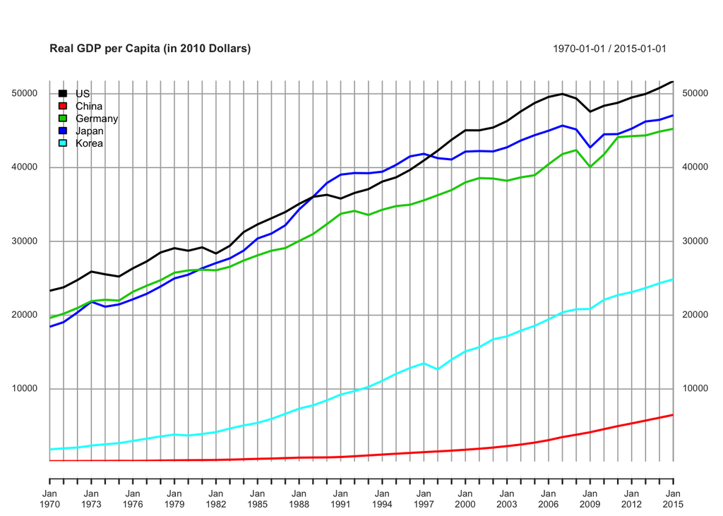

```r
us = getSymbols('NYGDPPCAPKDUSA',src='FRED',auto.assign=FALSE)
china = getSymbols('NYGDPPCAPKDCHN',src='FRED',auto.assign=FALSE)
germany = getSymbols('NYGDPPCAPKDDEU',src='FRED',auto.assign=FALSE)
japan = getSymbols('NYGDPPCAPKDJPN',src='FRED',auto.assign=FALSE)
korea = getSymbols('NYGDPPCAPKDKOR',src='FRED',auto.assign=FALSE)

us = us[t]
china = china[t]
germany = germany[t]
japan = japan[t]
korea = korea[t]

GDPcapita = cbind(us,china,germany,japan,korea)
colnames(GDPcapita) <- c("US","China","Germany","Japan","Korea")

plot(GDPcapita,legend.loc='topleft',auto.legend=TRUE,main="Real GDP per Capita (in 2010 Dollars)")
```

### 1.3

Largest growth: China; Second largest growth: Korea

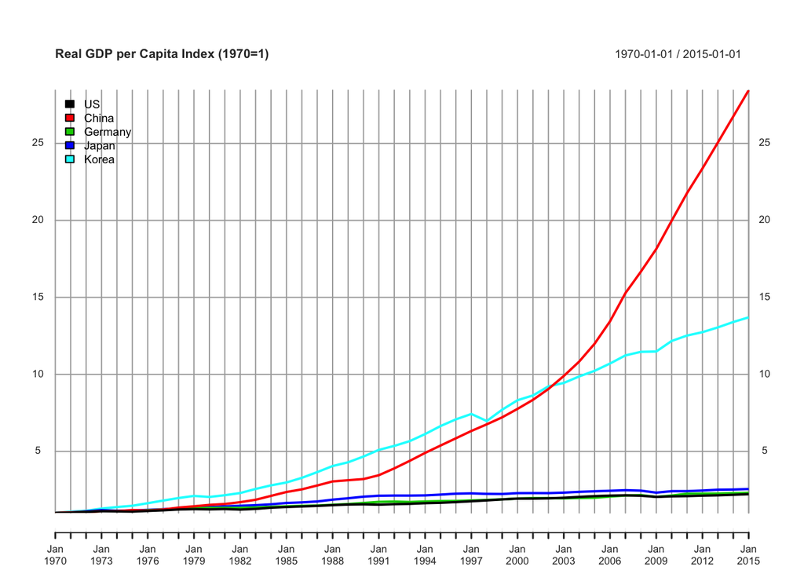

```r
us = us/coredata(us)[1]
china = china/coredata(china)[1]
germany = germany/coredata(germany)[1]
japan = japan/coredata(japan)[1]
korea = korea/coredata(korea)[1]

GDPcapitaIndex = cbind(us,china,germany,japan,korea)
colnames(GDPcapitaIndex) <- c("US","China","Germany","Japan","Korea")

plot(GDPcapitaIndex,legend.loc='topleft',auto.legend=TRUE,main="Real GDP per Capita Index (1970=1)")
```

## Problem 2

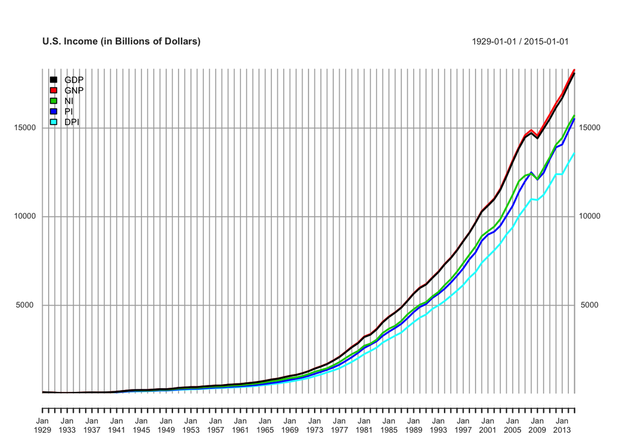

```r
t = "1929-01-01/2015-01-01"

gdp = getSymbols('GDPA',src='FRED',auto.assign=FALSE)
gnp = getSymbols('GNPA',src='FRED',auto.assign=FALSE)
ni = getSymbols('A032RC1A027NBEA',src='FRED',auto.assign=FALSE)
pi = getSymbols('A065RC1A027NBEA',src='FRED',auto.assign=FALSE)
dpi = getSymbols('A067RC1A027NBEA',src='FRED',auto.assign=FALSE)

data = cbind(gdp,gnp,ni,pi,dpi)
colnames(data) <- c("GDP","GNP","NI","PI","DPI")

plot(data[t],legend.loc='topleft',auto.legend=TRUE,main="U.S. Income (in Billions of Dollars)")
```

## Problem 3

### 3.1

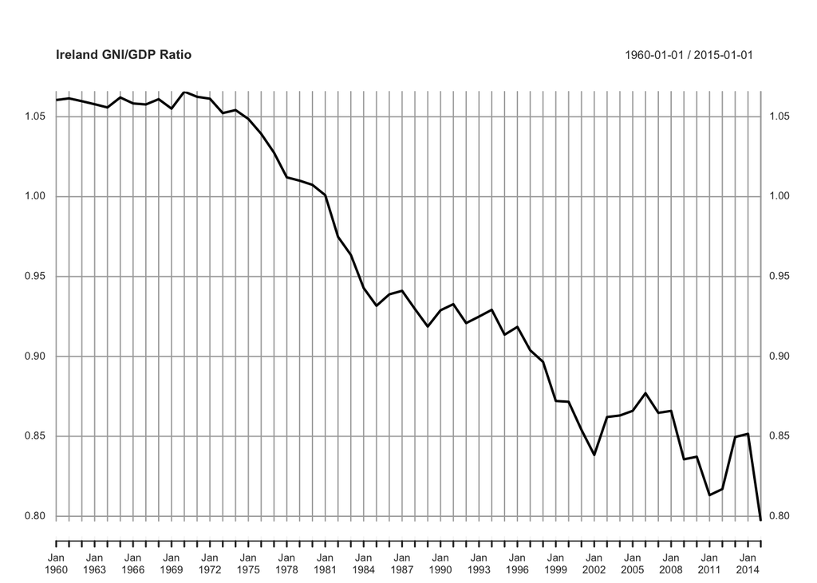

```r
t = "1960-01-01/2015-01-01"

gdp = getSymbols('MKTGDPIEA646NWDB',src='FRED',auto.assign=FALSE)
gni = getSymbols('MKTGNIIEA646NWDB',src='FRED',auto.assign=FALSE)

gdp = gdp[t]
gni = gni[t]
ratio = gni/gdp

plot(ratio,main="Ireland GNI/GDP Ratio")
```

### 3.2

FDI[^1]

## Problem 4

### 4.1

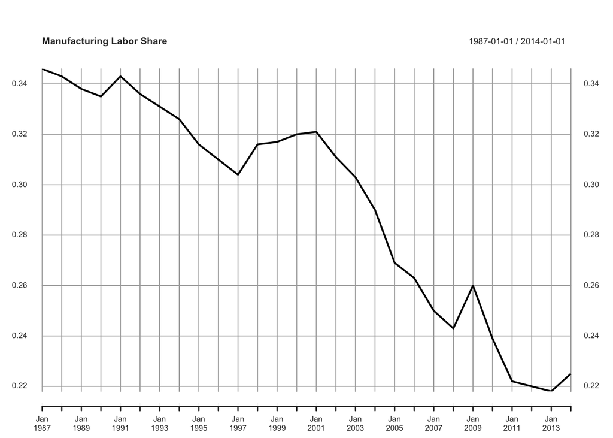

```r
t = "1987-01-01/2014-01-01"

ls = getSymbols('MPU9900681',src='FRED',auto.assign=FALSE)
durable = getSymbols('MPU9920681',src='FRED',auto.assign=FALSE)
nondurable = getSymbols('MPU9910681',src='FRED',auto.assign=FALSE)

plot(ls[t],main="Manufacturing Labor Share")
```

### 4.2

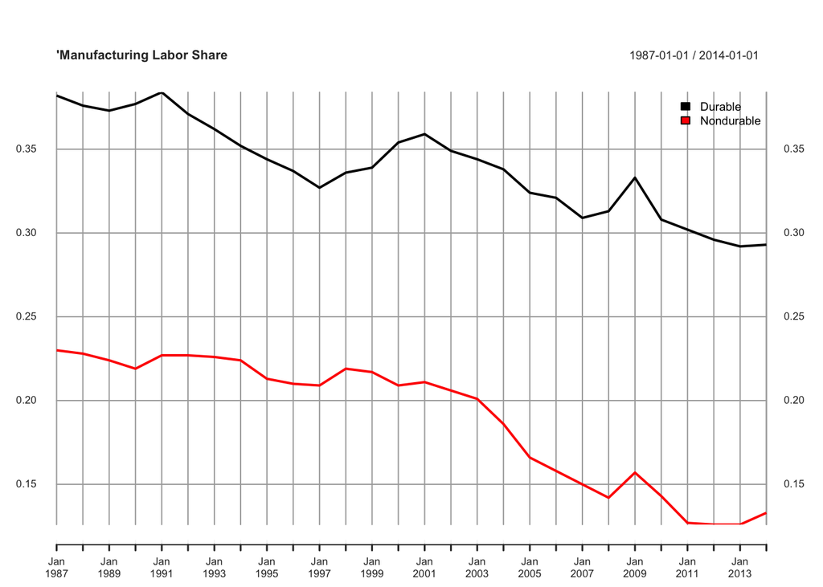

```r
data = cbind(durable,nondurable)
colnames(data) <- c("Durable","Nondurable")

plot(data[t],legend.loc='topright',auto.legend=TRUE,main="'Manufacturing Labor Share")
```

### 4.4

Technology growth, globalization (trade + outsourcing)

## Problem 5

### 5.1

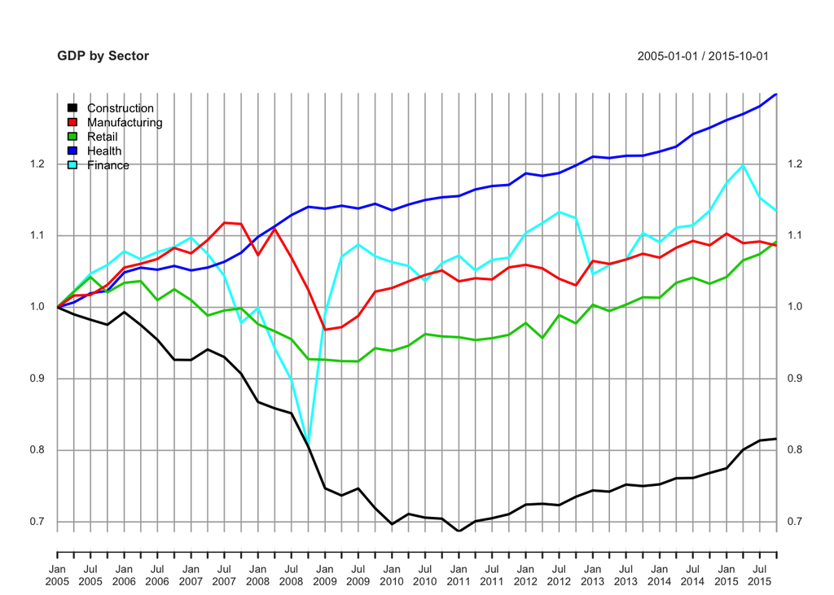

```r
t = "2005-01-01/2015-12-31"

con = getSymbols('USCONSTRQGSP',src='FRED',auto.assign=FALSE)
man = getSymbols('USMANRQGSP',src='FRED',auto.assign=FALSE)
retail = getSymbols('USRETAILRQGSP',src='FRED',auto.assign=FALSE)
health = getSymbols('USHLTHSOCASSRQGSP',src='FRED',auto.assign=FALSE)
fin = getSymbols('USFININSRQGSP',src='FRED',auto.assign=FALSE)

con = con[t]
man = man[t]
retail = retail[t]
health = health[t]
fin = fin[t]

con = con/coredata(con)[1]
man = man/coredata(man)[1]
retail = retail/coredata(retail)[1]
health = health/coredata(health)[1]
fin = fin/coredata(fin)[1]

data = cbind(con,man,retail,health,fin)
colnames(data) <- c("Construction","Manufacturing","Retail","Health","Finance")
plot(data,legend.loc='topleft',auto.legend=TRUE,main="GDP by Sector")
```

### 5.2

Construction started to decline first. The Financial sector experienced the most precipitous decline during the crisis but also recovered the fastest. Healthcare grew during the crisis. The Construction sector still hasn’t grown back to its 2005 level.

## Problem 6

### 6.1

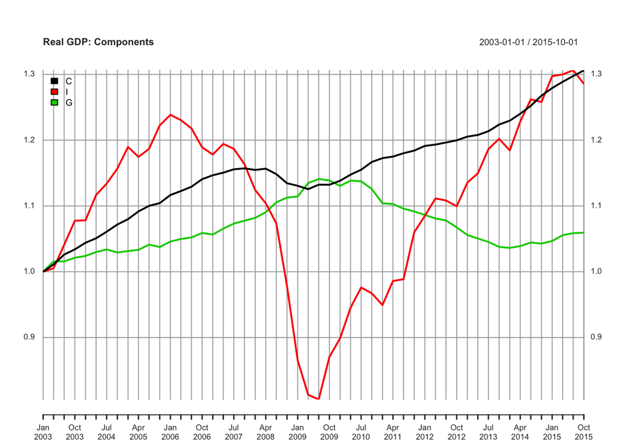

```r
t = "2003-01-01/2015-12-31"

rc = getSymbols('PCECC96',src='FRED',auto.assign=FALSE)
ri = getSymbols('GPDIC1',src='FRED',auto.assign=FALSE)
rg = getSymbols('GCEC1',src='FRED',auto.assign=FALSE)

rc = rc[t]
ri = ri[t]
rg = rg[t]

rc = rc/coredata(rc)[1]
ri = ri/coredata(ri)[1]
rg = rg/coredata(rg)[1]

data = cbind(rc,ri,rg)
colnames(data) <- c("C","I","G")
plot(data,legend.loc='topleft',auto.legend=TRUE,main="Real GDP: Components")
```

### 6.2

Investment started to decline in 2006.Q1 and experienced the most significant drop during the financial crisis. Consumption started to drop in 2008.Q2 and began to recover in 2009.Q2. Government spending increased during and immediately after the financial crisis.

## Problem 7

### 7.1

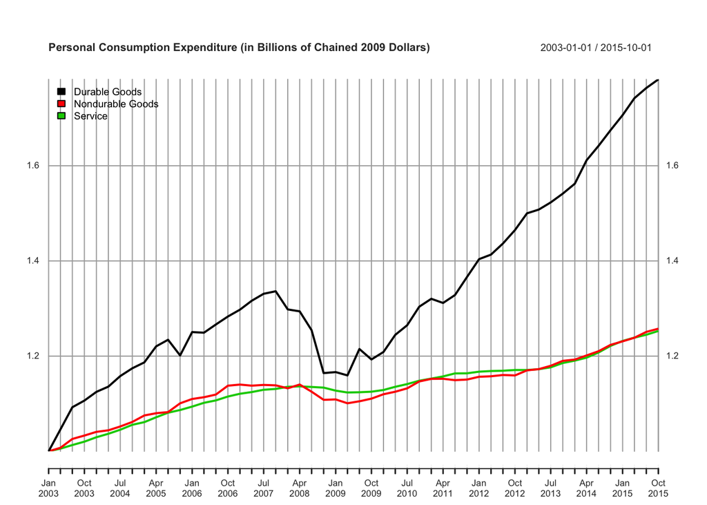

```r
t = "2003-01-01/2015-12-31"

durable = getSymbols('PCDGCC96',src='FRED',auto.assign=FALSE)
nondurable = getSymbols('PCNDGC96',src='FRED',auto.assign=FALSE)
service = getSymbols('PCESVC96',src='FRED',auto.assign=FALSE)

durable = durable[t]
nondurable = nondurable[t]
service = service[t]

durable = durable/coredata(durable)[1]
nondurable = nondurable/coredata(nondurable)[1]
service = service/coredata(service)[1]

data = cbind(durable,nondurable,service)
colnames(data) <- c('Durable Goods','Nondurable Goods','Service')
plot(data,legend.loc='topleft',auto.legend=TRUE,main="Personal Consumption Expenditure (in Billions of Chained 2009 Dollars)")
```

### 7.2

Consumption on durable goods dropped the most during the recession but also recovered and has seen the strongest growth post-recession. Service consumption was least affected by the recession.

## Problem 8

### 8.1

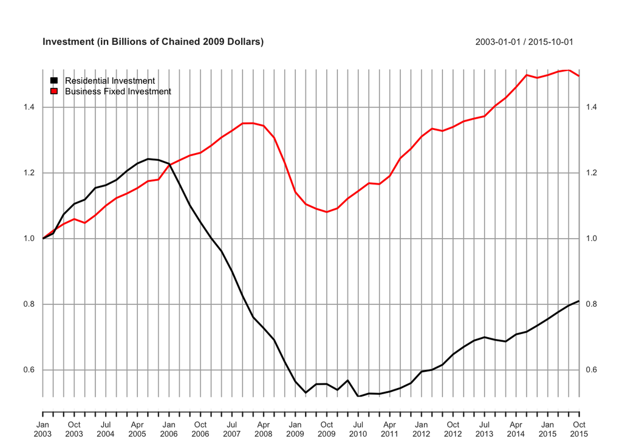

```r
t = "2003-01-01/2015-12-31"

ri = getSymbols('PRFIC96',src='FRED',auto.assign=FALSE)
bi = getSymbols('PNFIC96',src='FRED',auto.assign=FALSE)

ri = ri[t]
bi = bi[t]

ri = ri/coredata(ri)[1]
bi = bi/coredata(bi)[1]

data = cbind(ri,bi)
colnames(data) <- c('Residential Investment','Business Fixed Investment')
plot(data,legend.loc='topleft',auto.legend=TRUE,main="Investment (in Billions of Chained 2009 Dollars)")
```

### 8.2

Residential investment started to decline in mid-2005 and started to grow in mid-2010. Business fixed investment started to decline at the beginning of 2008 and started to recover toward the end of 2009. Today, residential investment still hasn’t recovered to its 2007 level.

[^1]: As we have discussed in class, part of the FDI is induced by Ireland’s tax incentives.